# Assignment 5 - Dimensionality reduction techniques

```r
date()
```

```
## [1] "Tue Dec  6 00:27:01 2022"
```

## Exploring the data

Here we look at the variables of the `human` data, that we made previously.

```r
#read the 'human' data set into memory
human <- read.csv("~/Documents/Tohtoritutkinto/Open Science/IODS-project/data/human.csv", row.names = 1)

summary(human)
```

```
##     Edu2.FM          Labo.FM          Life.Exp        Edu.Exp
##  Min.   :0.1717   Min.   :0.1857   Min.   :49.00   Min.   : 5.40
##  1st Qu.:0.7264   1st Qu.:0.5984   1st Qu.:66.30   1st Qu.:11.25
##  Median :0.9375   Median :0.7535   Median :74.20   Median :13.50
##  Mean   :0.8529   Mean   :0.7074   Mean   :71.65   Mean   :13.18
##  3rd Qu.:0.9968   3rd Qu.:0.8535   3rd Qu.:77.25   3rd Qu.:15.20
##  Max.   :1.4967   Max.   :1.0380   Max.   :83.50   Max.   :20.20
##       GNI            Mat.Mor         Ado.Birth         Parli.F
##  Min.   :   581   Min.   :   1.0   Min.   :  0.60   Min.   : 0.00
##  1st Qu.:  4198   1st Qu.:  11.5   1st Qu.: 12.65   1st Qu.:12.40
##  Median : 12040   Median :  49.0   Median : 33.60   Median :19.30
##  Mean   : 17628   Mean   : 149.1   Mean   : 47.16   Mean   :20.91
##  3rd Qu.: 24512   3rd Qu.: 190.0   3rd Qu.: 71.95   3rd Qu.:27.95
##  Max.   :123124   Max.   :1100.0   Max.   :204.80   Max.   :57.50
```

```r
#access GGally library
library(GGally)
```

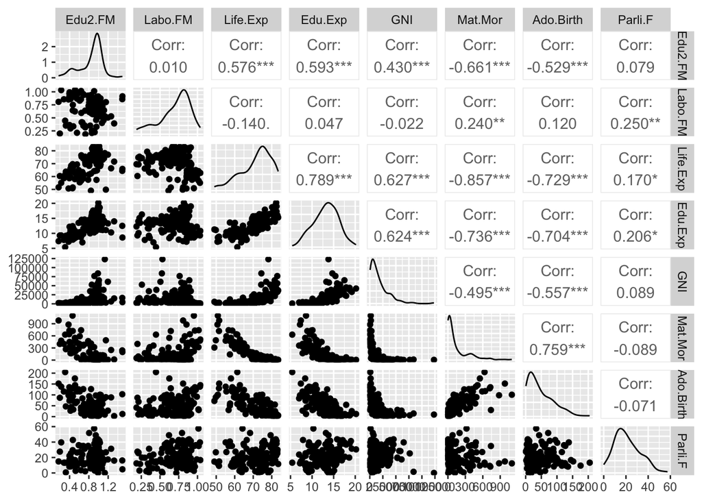

```r
#visualize the 'human' variables
ggpairs(human, progress = FALSE)
```

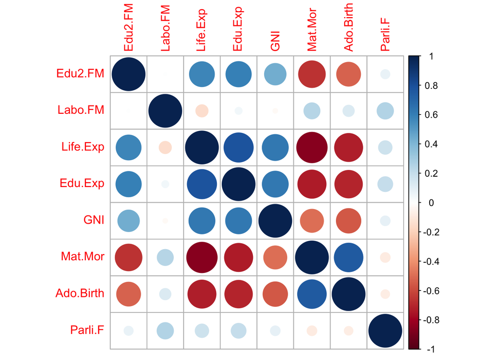

```r
#access corrplot library
library(corrplot)
#compute the correlation matrix and visualize it with corrplot
cor(human) %>% corrplot()
```

As we look at the summaries of the variables and the pairs plot, we can see that Gross National Income per capita (`GNI`), maternal mortality ratio (`Mat.Mor`) and adolescent birth rate (`Ado.Birth`) all have heavily right-skewed distributions. On the other hand, both Life expectancy (`Life.Exp`) and ratio of labor force participation of females and males (`Labo.FM`) have left-skewed distributions. The distribution ratio of female and male populations with secondary education has a positive kurtosis.

Looking at the pairs plot and correlation plot we notice that there are a few significant correlations between our variables. There is a high positive correlation between `Ado.Birth` and `Mat.Mor` (0.759). There is also a high negative correlation between `Life.Exp` and both `Mat.Mor` (-0.857) and `Ado.Birth` (-0.729). On the other hand, there is a high positive correlation between `Life.Exp` and expected years of schooling (`Edu.Exp`) (0.789). Lastly, there is a positive correlation between Gross National Income per capita (GNI) and both `Life.Exp` (0.627) and `Edu.Exp` (0.624).

## Principal component analysis

Next we perform the principal component analysis (PCA) on the raw (non-standardized) `human` data.

```r
#perform principal component analysis (with the singular value decomposition method)
pca_human <- prcomp(human)

#create a summary of pca_human
s <- summary(pca_human)

#rounded percentages of variance captured by each PC
pca_pr <- round(100*s$importance[2, ], digits = 2)

#print out the percentages of variance
pca_pr
```

```
##   PC1   PC2   PC3   PC4   PC5   PC6   PC7   PC8
## 99.99  0.01  0.00  0.00  0.00  0.00  0.00  0.00
```

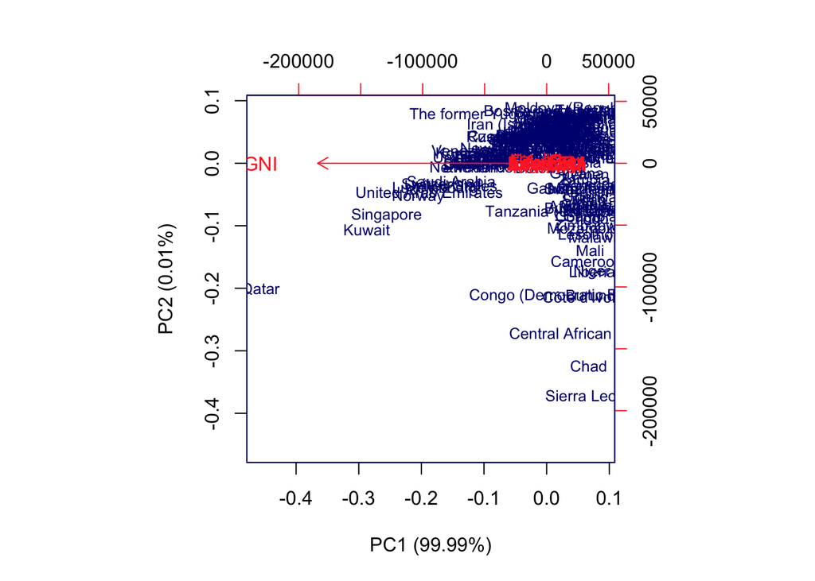

*PCA with raw data: PC1 explains almost all of the variance. GNI has a heavy negative loading on PC1, while the other variables do not seem to have a significant loading on either PC.*

```r
#create object pc_lab to be used as axis labels
pc_lab <- paste0(names(pca_pr), " (", pca_pr, "%)")

#draw a biplot of the principal component representation and the original variables
biplot(pca_human, choices = 1:2, cex = c(0.8, 1), col = c("navyblue", "firebrick1"), xlab = pc_lab[1], ylab = pc_lab[2])
```

Next we standardize the variables and repeat the above analysis.

```r
#standardize the variables
human_std <- scale(human)

#perform principal component analysis on the standardized variables (with the SVD method)
pca_human_std <- prcomp(human_std)

#create and print out a summary of pca_human_std
s2 <- summary(pca_human_std)

#rounded percentanges of variance captured by each PC
pca_pr2 <- round(100*s2$importance[2, ], digits = 2)

#print out the percentages of variance
pca_pr2
```

```
##   PC1   PC2   PC3   PC4   PC5   PC6   PC7   PC8
## 53.61 16.24  9.57  7.58  5.48  3.60  2.63  1.30
```

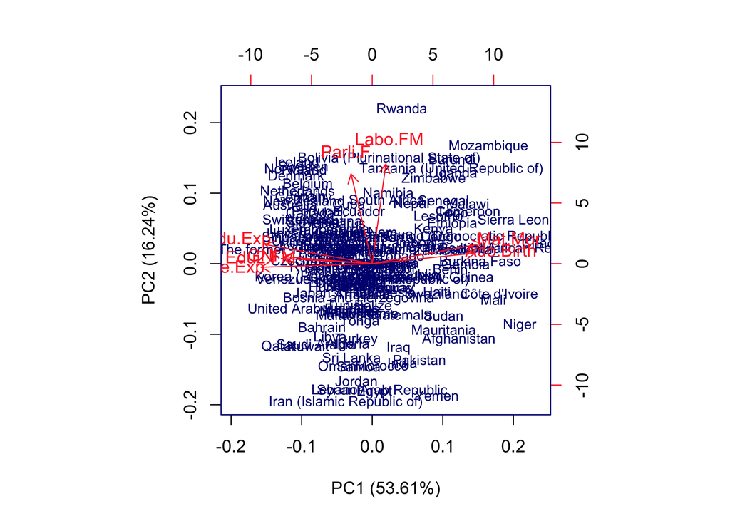

*PCA with standardized data: PC1 explains 53.61% of the variance, while PC2 explains 16.24%. Mat.Mor and Ado.Birth have both positive loading on PC1, while Edu2.FM, GNI, Edu.Exp and Life.Exp have negative loading on PC1. Parli.F and Labo.FM have both a positive loading on PC2. No variables seem to have a significant negative loading on PC2.*

```r
# create object pc_lab to be used as axis labels
pc_lab2 <- paste0(names(pca_pr2), " (", pca_pr2, "%)")

#draw a biplot of the principal component representation and the standardized variables
biplot(pca_human_std, choices = 1:2, cex = c(0.8, 1), col = c("navyblue", "firebrick1"), xlab = pc_lab2[1], ylab = pc_lab2[2])
```

As we can see, the results for the two PCAs are very different. In the first PCA using the non-standardized data, we see that the first principal component (PC1) explains almost all of the variance (99,99%) and the second principal component (PC2) explains only 00,01%. After standardization, PC1 explains 53,61% and PC2 explains 16,24% of the variance. I believe this difference is due to the different scaling of the raw variables. Looking at the previous section, we can see that `GNI`has a much larger scale compared to the other variables. This is evident in the first biplot, where the only arrow that is visible is GNI. This shows that the first PCA has loaded heavily on the `GNI` variable. Once the variables are standardized the scaling is very similar between variables and the PCA is no longer influenced by possible different variable scales.

My own interpretation of the first two principal component dimensions is that the PC1 relates to how developed the country is. The reasoning behind this comes from the variables related to PC1: Mat.Mor, Ado.Birth, Edu2.FM, GNI, Edu.Exp, Life.Exp. All of the variables are key factors when assessing the development stage of a country. This is further supported when looking at biplot as richer and more developed countries (e.g. many European nations) are on the left side while many poorer countries (e.g. many African nations) are on the right side. The PC2 seems to be related to female participation in society as the variables related to PC2 were Parli.F and Labo.FM. We can also notice that the countries that are furthest away from these variables are fairly male-centric (e.g. arabic nations).

## Multiple Correspondence Analysis

Next we will look at `tea` data. The tea data comes from the FactoMineR package and it is measured with a questionnaire on tea: 300 individuals were asked how they drink tea (18 questions) and what are their product’s perception (12 questions). In addition, some personal details were asked (4 questions). We will look at the dimensions and structure of the data and finally visualize it.

```r
#read tea data set into memory and convert character variables to factors
tea <- read.csv("https://raw.githubusercontent.com/KimmoVehkalahti/Helsinki-Open-Data-Science/master/datasets/tea.csv", stringsAsFactors = TRUE)

#look at the dimension and structure of the data
dim(tea)
```

```
## [1] 300  36
```

```r
str(tea)
```

```
## 'data.frame':    300 obs. of  36 variables:
##  $ breakfast       : Factor w/ 2 levels "breakfast","Not.breakfast": 1 1 2 2 1 2 1 2 1 1 ...
##  $ tea.time        : Factor w/ 2 levels "Not.tea time",..: 1 1 2 1 1 1 2 2 2 1 ...
##  $ evening         : Factor w/ 2 levels "evening","Not.evening": 2 2 1 2 1 2 2 1 2 1 ...
##  $ lunch           : Factor w/ 2 levels "lunch","Not.lunch": 2 2 2 2 2 2 2 2 2 2 ...
##  $ dinner          : Factor w/ 2 levels "dinner","Not.dinner": 2 2 1 1 2 1 2 2 2 2 ...
##  $ always          : Factor w/ 2 levels "always","Not.always": 2 2 2 2 1 2 2 2 2 2 ...
##  $ home            : Factor w/ 2 levels "home","Not.home": 1 1 1 1 1 1 1 1 1 1 ...
##  $ work            : Factor w/ 2 levels "Not.work","work": 1 1 2 1 1 1 1 1 1 1 ...
##  $ tearoom         : Factor w/ 2 levels "Not.tearoom",..: 1 1 1 1 1 1 1 1 1 2 ...
##  $ friends         : Factor w/ 2 levels "friends","Not.friends": 2 2 1 2 2 2 1 2 2 2 ...
##  $ resto           : Factor w/ 2 levels "Not.resto","resto": 1 1 2 1 1 1 1 1 1 1 ...
##  $ pub             : Factor w/ 2 levels "Not.pub","pub": 1 1 1 1 1 1 1 1 1 1 ...
##  $ Tea             : Factor w/ 3 levels "black","Earl Grey",..: 1 1 2 2 2 2 2 1 2 1 ...
##  $ How             : Factor w/ 4 levels "alone","lemon",..: 1 3 1 1 1 1 1 3 3 1 ...
```

[output cut: 22 more lines]

```r
#browse the contents of the data frame
View(tea)

#access dplyr library
library(dplyr)
#selecting columns to keep in the data set for visualization and MCA
keep_columns <- c("Tea", "How", "sugar", "how", "sex", "age_Q", "frequency")

#select the 'keep_columns' to create a new data set
tea_time <- select(tea, keep_columns)
```

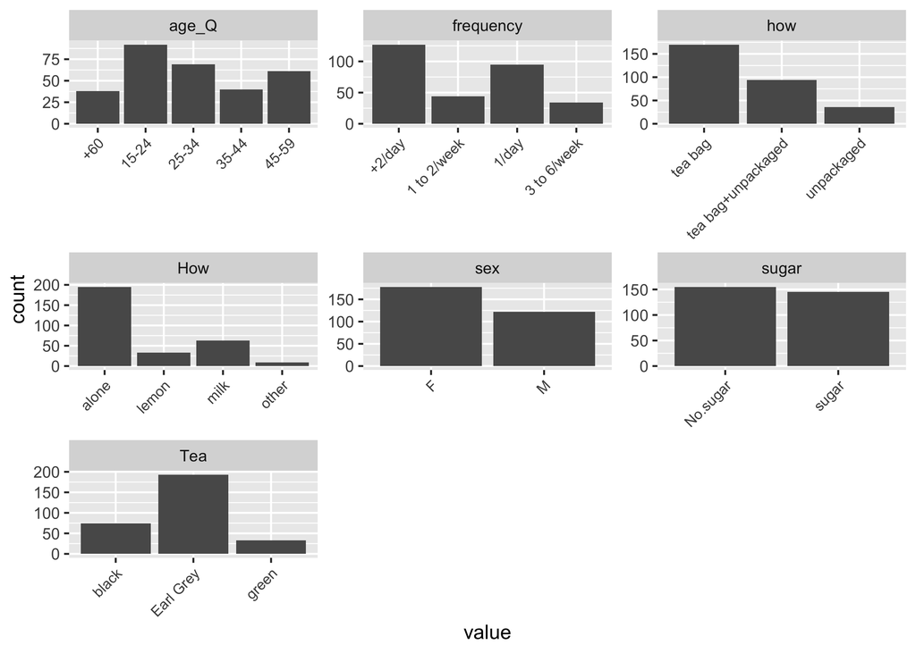

```r
#access the ggplot and tidyr library
library(ggplot2)
library(tidyr)

#visualize the data set
pivot_longer(tea_time, cols = everything()) %>%
  ggplot(aes(value)) + geom_bar() + theme(axis.text.x = element_text(angle = 45, hjust = 1, size = 8)) + facet_wrap("name", scales = "free")
```

Looking at the structure of the `tea` data frame, we see that there are 36 different variables and 300 observations. Almost all of the variables are factors except `age` which is an integer. For the visualization and upcoming analysis I chose seven variables that seemed interesting to me. From the visualization we can see that Earl Grey is the most popular tea variety. Most people drink their tea alone (without any additions). Most people drink tea at least once per day. Most people use tea bags. Use of sugar is fairly split between. There were slightly more females than males in the questionnaire. The most populous age quartile from the questionnaire was ages 15 to 24.

Next we do the multiple correspondence analysis (MCA) for the selected variables.

```r
#multiple correspondence analysis
library(FactoMineR)
mca <- MCA(tea_time, graph = FALSE)

#summary of the model
summary(mca)
```

```
##
## Call:
## MCA(X = tea_time, graph = FALSE)
##
##
## Eigenvalues
##                        Dim.1   Dim.2   Dim.3   Dim.4   Dim.5   Dim.6   Dim.7
## Variance               0.246   0.216   0.186   0.179   0.168   0.159   0.149
## % of var.             10.752   9.435   8.137   7.841   7.347   6.947   6.534
## Cumulative % of var.  10.752  20.187  28.324  36.165  43.512  50.459  56.993
##                        Dim.8   Dim.9  Dim.10  Dim.11  Dim.12  Dim.13  Dim.14
## Variance               0.145   0.130   0.123   0.122   0.113   0.101   0.095
## % of var.              6.358   5.701   5.396   5.358   4.933   4.419   4.171
## Cumulative % of var.  63.351  69.052  74.448  79.807  84.740  89.158  93.329
##                       Dim.15  Dim.16
## Variance               0.078   0.074
## % of var.              3.430   3.241
## Cumulative % of var.  96.759 100.000
##
## Individuals (the 10 first)
##              Dim.1    ctr   cos2    Dim.2    ctr   cos2    Dim.3    ctr   cos2
## 1         |  0.015  0.000  0.000 |  0.558  0.481  0.140 |  0.396  0.282  0.071
## 2         |  0.611  0.507  0.171 |  0.049  0.004  0.001 |  0.020  0.001  0.000
## 3         |  0.366  0.181  0.107 | -0.559  0.483  0.250 | -0.331  0.197  0.088
## 4         | -0.752  0.768  0.450 |  0.019  0.001  0.000 |  0.147  0.039  0.017
## 5         |  0.241  0.079  0.043 | -0.109  0.018  0.009 | -0.326  0.190  0.078
## 6         | -0.376  0.192  0.114 | -0.123  0.023  0.012 | -0.073  0.009  0.004
## 7         |  0.096  0.012  0.003 |  0.144  0.032  0.008 |  0.082  0.012  0.003
## 8         |  0.449  0.273  0.065 |  0.155  0.037  0.008 |  0.664  0.791  0.143
## 9         |  0.257  0.089  0.028 |  0.014  0.000  0.000 |  0.050  0.004  0.001
## 10        |  0.675  0.619  0.199 |  0.096  0.014  0.004 |  0.001  0.000  0.000
##
## 1         |
## 2         |
## 3         |
## 4         |
## 5         |
## 6         |
## 7         |
## 8         |
```

[output cut: 21 more lines]

```
## milk        0.375   2.267   0.037   3.342 |
## other       2.747  17.383   0.233   8.352 |
## No.sugar   -0.320   4.076   0.110  -5.730 |
## sugar       0.343   4.357   0.110   5.730 |
## tea bag     0.334   4.859   0.146   6.607 |
##
## Categorical variables (eta2)
##             Dim.1 Dim.2 Dim.3
## Tea       | 0.420 0.159 0.216 |
## How       | 0.110 0.067 0.340 |
## sugar     | 0.425 0.053 0.110 |
## how       | 0.084 0.171 0.150 |
## sex       | 0.045 0.517 0.000 |
## age_Q     | 0.478 0.403 0.421 |
## frequency | 0.159 0.140 0.065 |
```

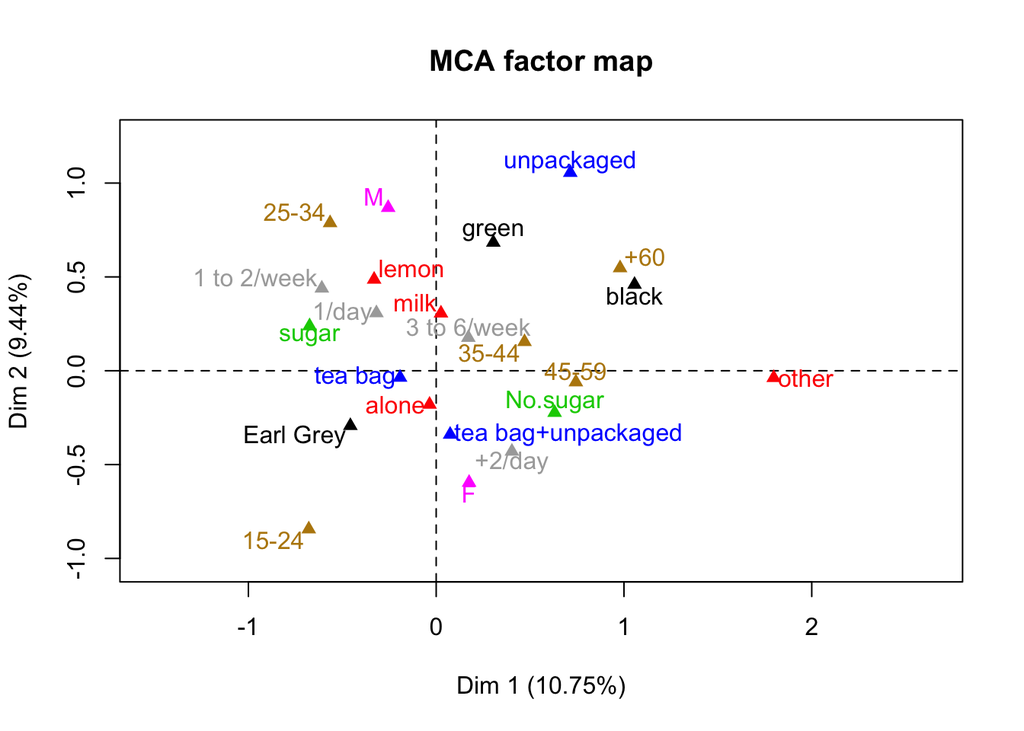

```r
#visualize MCA with the variable biplot
plot(mca, invisible=c("ind"), habillage = "quali", graph.type = "classic")
```

Looking at the variable biplot, we can see that the first two dimensions of the MCA capture 10.75% and 9.44% of the total variance. The horizontal dimension opposes “other” tea drinkers with the other options. The vertical dimension opposes male and female as well as unpackaged tea to the other options. It also seems to oppose Earl Grey form the other tea varieties. The age quartiles are linked to both dimensions. Looking at how the variables are spread, we can make the assumption that older men are more likely to use unpackaged tea of green and black variety than young females.